# NLS_GNSS_SOFAMESA

[figure not shown]

```
                Ohjeistuksia testimittausten analysointia varten / Guidance for Analyzing Test Measurements

                Author: Tuukka Mattila
                Do not hesitate to contact via LinkedIn:
                https://www.linkedin.com/in/tuukkamattila/

                Thank you for the help: Topi Rikkinen, Marko Ollikainen, Antti Laaksonen, Hannu Koivula, and Ari Huvinen
```

```python
from IPython.display import Markdown, display, YouTubeVideo, HTML
# display(Markdown('**Ohjeistuksia testimittausten analysointia varten / Guidance for Analyzing Test Measurements**'))
# https://ipython.readthedocs.io/en/stable/api/generated/IPython.display.html

# Use this, when no firewall problems:
display(YouTubeVideo('urj7mGjKY9Q', width=980, height=551.25, autoplay = 1, start = 53, loop = 1, playlist='urj7mGjKY9Q'))
# https://developers.google.com/youtube/player_parameters#Parameters

# Use this, when firewall problems:
# HTML('<iframe width="980" height="551.25" src="https://www.youtube.com/embed/urj7mGjKY9Q" frameborder="0" allow="accelerometer; autoplay; encrypted-media; gyroscope; picture-in-picture" allowfullscreen></iframe>')
```

[video not shown]

Laitetaan kello päälle ohjelman ajan mittaamiseksi. / Let's start the clock for the program to measure the time spent:

```python
import time
time_beginning = time.time()
```

Tuodaan tarvittavat kirjastot / Import necessary Python libraries:

```python
import numpy as np
from matplotlib import pyplot as plt
import pandas as pd
import seaborn as sns
import os
import sys
import math
import pathlib
import outlier_detection
```

Luodaan uusi kansio kuvaajille. / Let's create a new folder for the figures:

```python
try:
    pathlib.Path(pathlib.Path(pathlib.Path.cwd()).joinpath('figures')).mkdir()
except:
    print('Folder already exists. Use the existing folder location of the figures {}\\figures.'.format(str(pathlib.Path.cwd())))
```

```
Folder already exists. Use the existing folder location of the figures C:\Omat\Jupyter Notebook\figures.
```

Testidataa pitää olla vähintään 3600 havaintoa per piste. Täyttyykö ehto? Esimerkiksi 10 sekunnin havaintojaksolla ja 1 epookin tallennusvälillä keskiarvoistettuja ratkaisuja tulisi olla 3600 kpl. Onko tiedostossa vähintään 3600 mittaustulosta pisteelle?

Tuodaan data .csv-muodossa, eroteltuna ","-merkillä ja muotoiltuna (sarakkeiden järjestyksellä ei ole väliä) [Point Number,Code,Date,Time,Time Stamp,Epocs Count,Solution,Physical Station ID,Virtual Station ID,Northing,Easting,Elev,Lat,Lon,Ell Ht,Ant Ht,HRMS,VRMS,HDOP,VDOP,PDOP,GDOP,TDOP,GPS,GLONASS,GALILEO,BEIDOU,SBAS,QZSS,Delta N,Delta E,Delta Elev,Azimuth,Slant Distance,Vertical Angle,Base Antenna Type,Rover Antenna Type,dX (mm),dY (mm),e,SigmaX,SigmaY,SigmaZ,CorXY,CorXZ,CorYZ,CovXY,CovXZ,CovYZ,Tilt X,Tilt Y,Heading,Sigma Tilt X,Sigma Tilt Y,Sigma Heading,Magnetic Field] (KESKEN) /

The test data should consist of at least 3600 measurements per reference point. Is the requirement met? For example, with 10 seconds measurement time and 1 second epocs, averaged solutions should be 3600 pcs. Does the file consist of at least 3600 measurements for the point?

Import the data in .csv and separated with "," and formatted as (the order of the columns doesn't matter) [Point Number,Code,Date,Time,Time Stamp,Epocs Count,Solution,Physical Station ID,Virtual Station ID,Northing,Easting,Elev,Lat,Lon,Ell Ht,Ant Ht,HRMS,VRMS,HDOP,VDOP,PDOP,GDOP,TDOP,GPS,GLONASS,GALILEO,BEIDOU,SBAS,QZSS,Delta N,Delta E,Delta Elev,Azimuth,Slant Distance,Vertical Angle,Base Antenna Type,Rover Antenna Type,dX (mm),dY (mm),e,SigmaX,SigmaY,SigmaZ,CorXY,CorXZ,CorYZ,CovXY,CovXZ,CovYZ,Tilt X,Tilt Y,Heading,Sigma Tilt X,Sigma Tilt Y,Sigma Heading,Magnetic Field] (IN PROGRESS):

```python
testmeasurements_df = pd.read_csv(input("Enter the name of the testmeasurements file (.csv). The data has to be formatted as (Point Number,Code,Date,Time,Time Stamp,Epocs Count,Solution,Physical Station ID,Virtual Station ID,Northing,Easting,Elev,Lat,Lon,Ell Ht,Ant Ht,HRMS,VRMS,HDOP,VDOP,PDOP,GDOP,TDOP,GPS,GLONASS,GALILEO,BEIDOU,SBAS,QZSS,Delta N,Delta E,Delta Elev,Azimuth,Slant Distance,Vertical Angle,Base Antenna Type,Rover Antenna Type,dX (mm),dY (mm),e,SigmaX,SigmaY,SigmaZ,CorXY,CorXZ,CorYZ,CovXY,CovXZ,CovYZ,Tilt X,Tilt Y,Heading,Sigma Tilt X,Sigma Tilt Y,Sigma Heading,Magnetic Field) and the file has to be located in the same folder as this Jupyter Notebook file:"), delimiter=',')
# assert os.path.exists(testmeasurements_df), "The file couldn't be found from {}, please try again!".format(str(testmeasurements_df))
# f = open(testmeasurements_df,'r+')
# print("File found!")
# f.close()
# print(testmeasurements_df)

# testmeasurements_df = pd.read_csv('test_measurements_example.csv', sep = ',')
# print(testmeasurements_df)
```

```
Enter the name of the testmeasurements file (.csv). The data has to be formatted as (Point Number,Code,Date,Time,Time Stamp,Epocs Count,Solution,Physical Station ID,Virtual Station ID,Northing,Easting,Elev,Lat,Lon,Ell Ht,Ant Ht,HRMS,VRMS,HDOP,VDOP,PDOP,GDOP,TDOP,GPS,GLONASS,GALILEO,BEIDOU,SBAS,QZSS,…
```

Analysoidaan satelliittidataa / Let's analyze the satellite data:

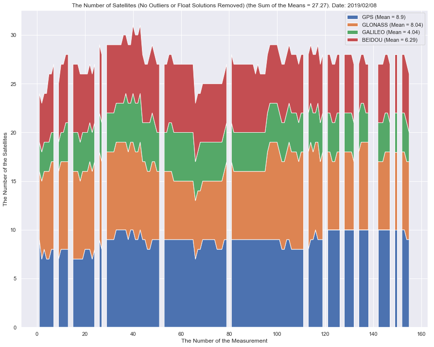

```python
x = range(len(testmeasurements_df.loc[:, 'GPS']))
y = [testmeasurements_df.loc[:, 'GPS'], testmeasurements_df.loc[:, 'GLONASS'], testmeasurements_df.loc[:, 'GALILEO'], testmeasurements_df.loc[:, 'BEIDOU']]
date = testmeasurements_df.loc[:, 'Date']

mean_GPS = round(testmeasurements_df.loc[:, 'GPS'].mean(), 2)
mean_GLONASS = round(testmeasurements_df.loc[:, 'GLONASS'].mean(), 2)
mean_GALILEO = round(testmeasurements_df.loc[:, 'GALILEO'].mean(), 2)
mean_BEIDOU = round(testmeasurements_df.loc[:, 'BEIDOU'].mean(), 2)
mean_total = round(testmeasurements_df.loc[:, 'GPS'].mean() + testmeasurements_df.loc[:, 'GLONASS'].mean() + testmeasurements_df.loc[:, 'GALILEO'].mean() + testmeasurements_df.loc[:, 'BEIDOU'].mean(), 2)

sns.set(style="darkgrid")
fig = plt.figure(figsize=(15, 12))
plt.stackplot(x, y, labels=['GPS (Mean = {})'.format(mean_GPS),'GLONASS (Mean = {})'.format(mean_GLONASS),'GALILEO (Mean = {})'.format(mean_GALILEO), 'BEIDOU (Mean = {})'.format(mean_BEIDOU)])
plt.title('The Number of Satellites (No Outliers or Float Solutions Removed) (the Sum of the Means = {}). Date: {}'.format(mean_total, date[1]))
plt.xlabel('The Number of the Measurement')
plt.ylabel('The Number of the Satellites')
plt.legend(loc='upper right')
fig.savefig('{}\\figures\\A_The Number of Satellites (No Outliers or Float Solutions Removed).png'.format(str(pathlib.Path.cwd())))
plt.show()

# luodaan DataFrame kuvaajien kuville myöhempää PDF-tiedostoa varten / create a DataFrame for the pictures of the figures for later .pdf file creation:
fig1 = {'The Figure File Name': ['A_The Number of Satellites (No Outliers or Float Solutions Removed).png']}
figures_df = pd.DataFrame(data = fig1)
```

Analysoidaan DOP-arvoja / Let's analyze the DOP values:

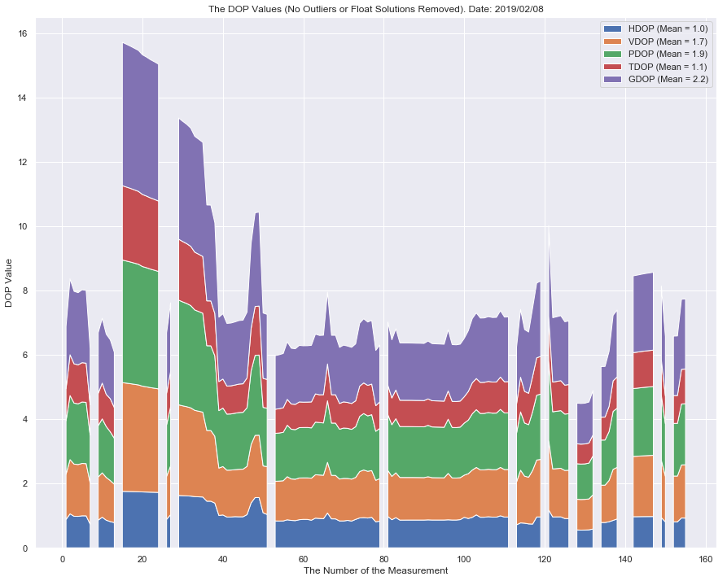

```python
x = range(len(testmeasurements_df.loc[:, 'HDOP']))
y = [testmeasurements_df.loc[:, 'HDOP'], testmeasurements_df.loc[:, 'VDOP'], testmeasurements_df.loc[:, 'PDOP'], testmeasurements_df.loc[:, 'TDOP'], testmeasurements_df.loc[:, 'GDOP']]
mean_HDOP = round(testmeasurements_df.loc[:, 'HDOP'].mean(), 1)
mean_VDOP = round(testmeasurements_df.loc[:, 'VDOP'].mean(), 1)
mean_PDOP = round(testmeasurements_df.loc[:, 'PDOP'].mean(), 1)
mean_TDOP = round(testmeasurements_df.loc[:, 'TDOP'].mean(), 1)
mean_GDOP = round(testmeasurements_df.loc[:, 'GDOP'].mean(), 1)

fig = plt.figure(figsize=(15, 12))
plt.stackplot(x, y, labels=['HDOP (Mean = {})'.format(mean_HDOP), 'VDOP (Mean = {})'.format(mean_VDOP), 'PDOP (Mean = {})'.format(mean_PDOP), 'TDOP (Mean = {})'.format(mean_TDOP), 'GDOP (Mean = {})'.format(mean_GDOP)])
plt.title('The DOP Values (No Outliers or Float Solutions Removed). Date: {}'.format(date[1]))
plt.xlabel('The Number of the Measurement')
plt.ylabel('DOP Value')
plt.legend(loc='upper right')
fig.savefig('{}\\figures\\B_The DOP Values (No Outliers or Float Solutions Removed).png'.format(str(pathlib.Path.cwd())))
plt.show()

figures_df.loc[1, 'The Figure File Name'] = 'B_The DOP Values (No Outliers or Float Solutions Removed).png'
```

Analysoidaan laitteen ilmoittamia HRMS- ja VRMS-arvoja / Let's analyze the HRMS and VRMS Quality Control (QC) values of the receiver:

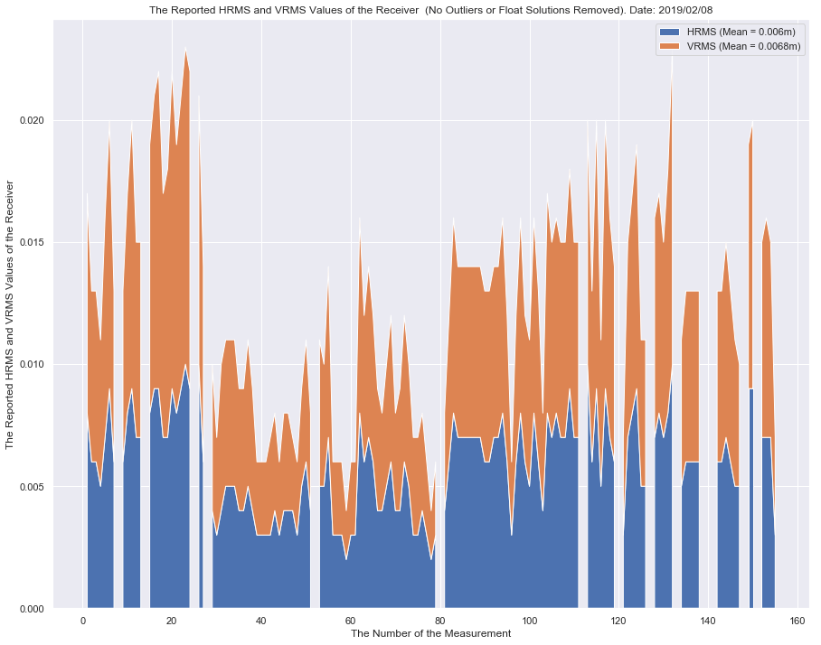

```python
x = range(len(testmeasurements_df.loc[:, 'HRMS']))
y = [testmeasurements_df.loc[:, 'HRMS'], testmeasurements_df.loc[:, 'VRMS']]
mean_HRMS = round(testmeasurements_df.loc[:, 'HRMS'].mean(), 4)
mean_VRMS = round(testmeasurements_df.loc[:, 'VRMS'].mean(), 4)

fig = plt.figure(figsize=(15, 12))
plt.stackplot(x, y, labels=['HRMS (Mean = {}m)'.format(mean_HRMS),'VRMS (Mean = {}m)'.format(mean_VRMS)])
plt.title('The Reported HRMS and VRMS Values of the Receiver  (No Outliers or Float Solutions Removed). Date: {}'.format(date[1]))
plt.xlabel('The Number of the Measurement')
plt.ylabel('The Reported HRMS and VRMS Values of the Receiver')
plt.legend(loc='upper right')
fig.savefig('{}\\figures\\C_The Reported HRMS and VRMS Values of the Receiver  (No Outliers or Float Solutions Removed).png'.format(str(pathlib.Path.cwd())))
plt.show()

figures_df.loc[2, 'The Figure File Name'] = 'C_The Reported HRMS and VRMS Values of the Receiver  (No Outliers or Float Solutions Removed).png'
```

Kysytään kaikkien pisteiden referenssikoordinaattien .csv-tiedostoa muodossa [Reference Point Number,Northing,Easting,Elevation] / Let's ask a .csv file of the reference coordinates of the points, formatted as [Reference Point Number,Northing,Easting,Elevation]:

```python
referencecoordinates_df = pd.read_csv(input("Enter the name of the reference points file (.csv). The data has to be formatted as (Reference Point Number,Northing,Easting,Elevation) and the file has to be located in the same folder as this Jupyter Notebook file:"), delimiter=',')
# referencecoordinates_df = pd.read_csv('reference_points_example.csv', sep = ',')
# print(referencecoordinates_df)

referencepoint_number = int(input('Enter the Reference Point Number. THE VALUE HAS TO BE FOUND FROM THE REFERENCE POINT NUMBER .csv FILE AND IT HAS TO BE AN INTEGER VALUE > 0: '))
# referencepoint_number = 123

while referencepoint_number < 0 or referencecoordinates_df.loc[referencecoordinates_df['Reference Point Number'] == referencepoint_number].empty is True:
    print("That's not a valid Reference Point Number! Try again!")
    referencepoint_number = int(input('Enter the Reference Point Number. THE VALUE HAS TO BE FOUND FROM THE REFERENCE POINT NUMBER .csv FILE AND IT HAS TO BE AN INTEGER VALUE > 0: '))

referencepoint_number_df = referencecoordinates_df.loc[referencecoordinates_df['Reference Point Number'] == referencepoint_number].reset_index()
referencecoordinate_n = referencepoint_number_df.loc[0,'Northing']
referencecoordinate_e = referencepoint_number_df.loc[0,'Easting']
referencecoordinate_h = referencepoint_number_df.loc[0,'Elevation']
# print(referencecoordinate_n, referencecoordinate_e, referencecoordinate_h)
```

```
Enter the name of the reference points file (.csv). The data has to be formatted as (Reference Point Number,Northing,Easting,Elevation) and the file has to be located in the same folder as this Jupyter Notebook file:reference_points_example.csv
Enter the Reference Point Number. THE VALUE HAS TO BE FOUND FROM THE REFERENCE POINT NUMBER .csv FILE AND IT HAS TO BE AN INTEGER VALUE > 0: 123
```

Lisätään testimittausten pohjois-, itä- ja korkeuskoordinaatit omiin muuttujiinsa / Let's add the Norting, Easting and Elevation coordinates of the test measurements to their own variables:

```python
northcoordinates = testmeasurements_df.loc[:, 'Northing']
eastcoordinates = testmeasurements_df.loc[:, 'Easting']
heights = testmeasurements_df.loc[:, 'Elev']
# print(northcoordinates, eastcoordinates, heights)
```

Lasketaan koordinaattien erotukset keskiarvoistaan (mahdolliset outlierit mukaan luettuina) / Let's calculate the differences between the coordinates and their means (possible outliers included):

```python
def errors_outlierpossibility(coordinates1, mean1, coordinates2, mean2, coordinates3, mean3):
    errors_outlierpossibility = np.zeros(shape=(len(coordinates1), 3))
    i = 0
    while i < len(coordinates1):
        errors_outlierpossibility[i, 0] = abs(coordinates1.loc[i] - mean1)
        errors_outlierpossibility[i, 1] = abs(coordinates2.loc[i] - mean2)
        errors_outlierpossibility[i, 2] = abs(coordinates3.loc[i] - mean3)
        i += 1
    return errors_outlierpossibility

mean_n_outlierpossibility = np.mean(northcoordinates, axis = 0)
mean_e_outlierpossibility = np.mean(eastcoordinates, axis = 0)
mean_h_outlierpossibility = np.mean(heights, axis = 0)
# print(northcoordinates, eastcoordinates, heights, len(northcoordinates))

errors_outlierpossibility = errors_outlierpossibility(northcoordinates, mean_n_outlierpossibility, eastcoordinates, mean_e_outlierpossibility, heights, mean_h_outlierpossibility)
errors_outlierpossibility_df = pd.DataFrame({'North Errors (m)':errors_outlierpossibility[:,0],'East Errors (m)':errors_outlierpossibility[:,1],'Height Errors (m)':errors_outlierpossibility[:,2]})
# print(errors_outlierpossibility_df)
```

Piirretään KDE-kuvaajat (Kernel Density Estimator) outliereiden visuaalista tunnistamista varten / Let's draw KDE plots (Kernel Density Estimator) for visual outlier detection:

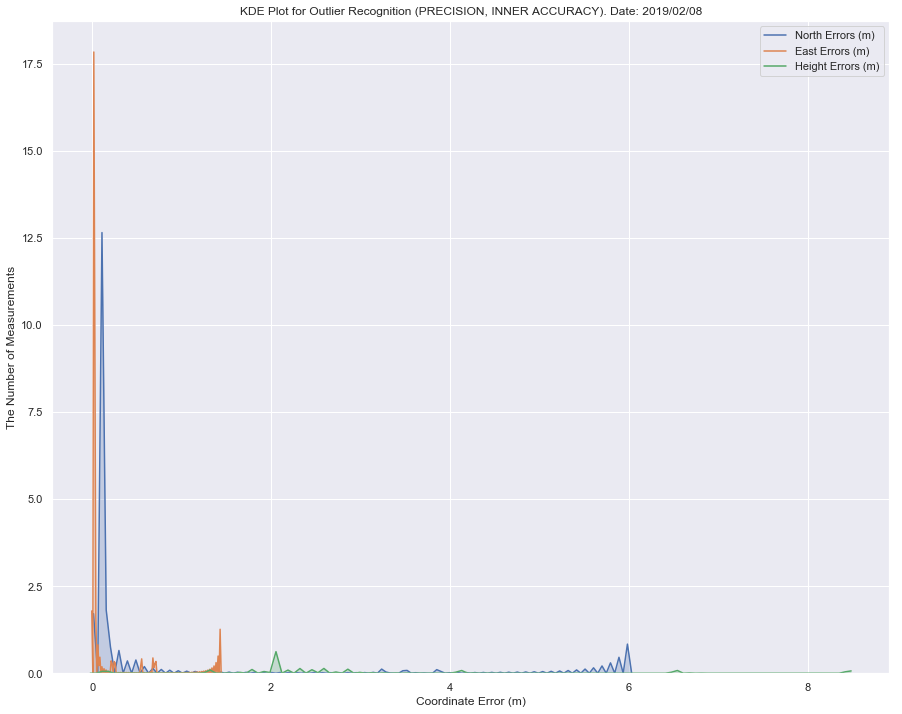

```python
fig = plt.figure(figsize=(15, 12))
ax1 = sns.kdeplot(errors_outlierpossibility_df['North Errors (m)'], shade=True)
ax2 = sns.kdeplot(errors_outlierpossibility_df['East Errors (m)'], shade=True)
ax3 = sns.kdeplot(errors_outlierpossibility_df['Height Errors (m)'], shade=True)
ax1.set_title('KDE Plot for Outlier Recognition (PRECISION, INNER ACCURACY). Date: {}'.format(date[1]))
ax1.set_xlabel('Coordinate Error (m)')
ax1.set_ylabel('The Number of Measurements')
fig.savefig('{}\\figures\\D_KDE Plot for Outlier Recognition (PRECISION, INNER ACCURACY).png'.format(str(pathlib.Path.cwd())))
plt.show()

figures_df.loc[3, 'The Figure File Name'] = 'D_KDE Plot for Outlier Recognition (PRECISION, INNER ACCURACY).png'
```

Edelliseen kuvaajaan perustuen tarkistetaan koordinaattien mediaanit, keskiarvot ja keskihajonnat (pohjoinen, itä, korkeus). Lisäksi tunnistetaan outlier-havainnot, jos ne ylittävät käyttäjän määrittämän poikkeaman pohjois- tai itäsuunnassa sekä korkeussuunnassa mediaaneistaan. / Based on the previous figure, let's check the medians, means and standard deviations of the coordinates (Northing, Easting, Elevation). Furthermore, let's recognize the outlier measurements, if they exceed the user-defined tolerances, which are calculated as differences from the medians of Northing or Easting and Elevation coordinates:

```python
tolerance_north_east = float(input('Enter a single tolerance value (m) for both North and East, which will be used to remove outliers from the measurements (for example 0.1; THE VALUE HAS TO BE POSITIVE: '))
tolerance_height = float(input('Enter a single tolerance value (m) for Height, which will be used to remove outliers from the measurements (for example 0.2; THE VALUE HAS TO BE POSITIVE: '))
# tolerance_north_east = 0.1
# tolerance_height = 0.2


while tolerance_north_east < 0 or tolerance_height < 0 or tolerance_north_east is None or tolerance_height is None:
    print("Those aren't valid numbers! Try again")
    tolerance_north_east = float(input('Enter a single tolerance value (m) for both North and East, which will be used to remove outliers from the measurements (for example 0.1; THE VALUE HAS TO BE POSITIVE: '))
    tolerance_height = float(input('Enter a single tolerance value (m) for Height, which will be used to remove outliers from the measurements (for example 0.1; THE VALUE HAS TO BE POSITIVE: '))

median_n = np.median(northcoordinates, axis = 0)
median_e = np.median(eastcoordinates, axis = 0)
median_h = np.median(heights, axis = 0)

(northcoordinates, eastcoordinates, heights, abovetolerances, testmeasurements_df_no_outliers, testmeasurements_df_outliers) = outlier_detection.outliers(np, pd, tolerance_north_east, tolerance_height, northcoordinates, median_n, eastcoordinates, median_e, heights, median_h, testmeasurements_df)

#print(northcoordinates)
#print(eastcoordinates)
#print(heights)
#print(abovetolerances)
#print(testmeasurements_df_no_outliers)
#print(testmeasurements_df_outliers)

median_n = np.median(northcoordinates, axis = 0)
median_e = np.median(eastcoordinates, axis = 0)
median_h = np.median(heights, axis = 0)

mean_n = np.mean(northcoordinates, axis = 0)
mean_e = np.mean(eastcoordinates, axis = 0)
mean_h = np.mean(heights, axis = 0)

std_n = np.std(northcoordinates, axis = 0)
std_e = np.std(eastcoordinates, axis = 0)
std_h = np.std(heights, axis = 0)

print('North and East coordinates and Heights means are: {}m, {}m and {}m.'.format(round(mean_n, 4), round(mean_e, 4), round(mean_h, 4)))
print('North and East coordinates and Heights medians are: {}m, {}m and {}m.'.format(round(median_n, 4), round(median_e, 4), round(median_h, 4)))
print('North and East coordinates and Heights standard deviations are: {}m, {}m and {}m.'.format(round(std_n, 4), round(std_e, 4), round(std_h, 4)))
```

```
Enter a single tolerance value (m) for both North and East, which will be used to remove outliers from the measurements (for example 0.1; THE VALUE HAS TO BE POSITIVE: 0.1
Enter a single tolerance value (m) for Height, which will be used to remove outliers from the measurements (for example 0.2; THE VALUE HAS TO BE POSITIVE: 0.2
Above tolerances 15 measurements of 156 measurements. Above tolerances percentage was 9.62 % of all measurements.
North and East coordinates and Heights means are: 6687057.9331m, 364944.1966m and 100.0494m.
North and East coordinates and Heights medians are: 6687057.9305m, 364944.1936m and 100.051m.
North and East coordinates and Heights standard deviations are: 0.0154m, 0.0127m and 0.0251m.
```

Piirretään jakaumat havaintojen virheistä (ei outliereitä mukana) / Let's draw the distributions of the measurement errors (no outliers):

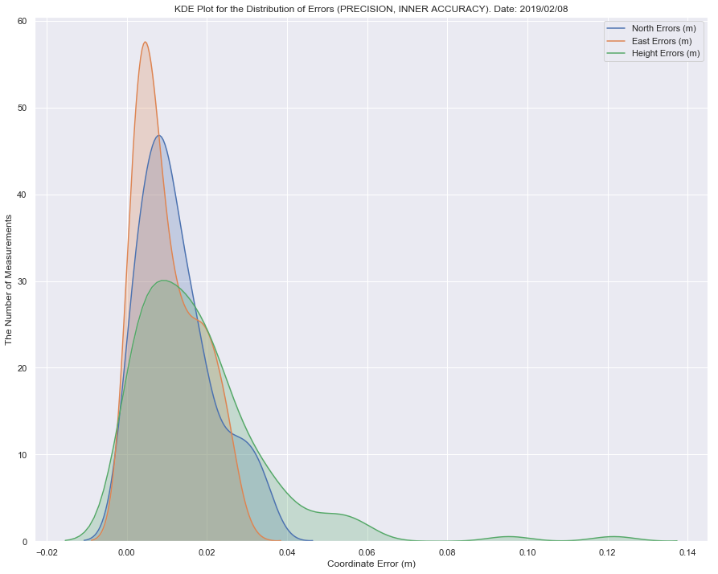

```python
def errors(coordinates1, mean1, coordinates2, mean2, coordinates3, mean3):
    errors = np.zeros(shape=(len(coordinates1), 3))
    i = 0
    while i < len(coordinates1):
        errors[i, 0] = abs(coordinates1[i] - mean1)
        errors[i, 1] = abs(coordinates2[i] - mean2)
        errors[i, 2] = abs(coordinates3[i] - mean3)
        i += 1
    return errors

errors = errors(northcoordinates, mean_n, eastcoordinates, mean_e, heights, mean_h)
errors_df = pd.DataFrame({'North Errors (m)':errors[:,0],'East Errors (m)':errors[:,1],'Height Errors (m)':errors[:,2]})

mean_n_error = round(errors_df.loc[:, 'North Errors (m)'].mean(), 4)
mean_e_error = round(errors_df.loc[:, 'East Errors (m)'].mean(), 4)
mean_h_error = round(errors_df.loc[:, 'Height Errors (m)'].mean(), 4)

std_n_error = round(errors_df.loc[:, 'North Errors (m)'].std(), 4)
std_e_error = round(errors_df.loc[:, 'East Errors (m)'].std(), 4)
std_h_error = round(errors_df.loc[:, 'Height Errors (m)'].std(), 4)

fig = plt.figure(figsize=(15, 12))
ax1 = sns.kdeplot(errors_df['North Errors (m)'], shade=True)
ax2 = sns.kdeplot(errors_df['East Errors (m)'], shade=True)
ax3 = sns.kdeplot(errors_df['Height Errors (m)'], shade=True)
ax1.set_title('KDE Plot for the Distribution of Errors (PRECISION, INNER ACCURACY). Date: {}'.format(date[1]))
ax1.set_xlabel('Coordinate Error (m)')
ax1.set_ylabel('The Number of Measurements')
fig.savefig('{}\\figures\\E_KDE Plot for the Distribution of Errors (PRECISION, INNER ACCURACY).png'.format(str(pathlib.Path.cwd())))
plt.show()

figures_df.loc[4, 'The Figure File Name'] = 'E_KDE Plot for the Distribution of Errors (PRECISION, INNER ACCURACY).png'
```

Testataan, miten hyvin yllä oleva aineisto asettuu normaalijakauman mukaiseksi. Tuotetaan yllä olevan aineiston keskiarvojen ja -hajontojen avulla malli normaalijakaumalle. Hyödynnetään satunnaisen numeron tuottamista mallin luomiseksi ja lasketaan normaalijakaumat. Voit testata eri otoskoolla mallia. (KESKEN) / Let's test, how well the data above can be fitted to follow the Gaussian distribution. We can produce a Gaussian distribution model with the help of the means and standard deviations of the test measurements. Let's utilize random number generation to produce the model and calculate distributions. You can test the model with varying sample sizes (IN PROGRESS):

```
Enter the sample size (for example 10, 100, 1000 or 10000; THE VALUES HAS TO BE BETWEEN 1-20000 AND AN INTEGER): 10000
```

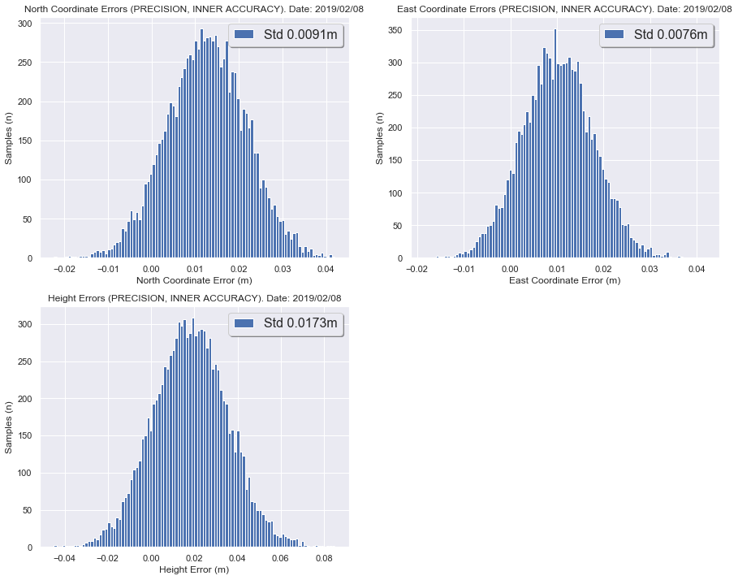

```python
def maximum_y(plt, normaldistribution_component_error, bins):
    y, x, _ = plt.hist(normaldistribution_component_error, bins)
    return y.max()

size = int(input('Enter the sample size (for example 10, 100, 1000 or 10000; THE VALUES HAS TO BE BETWEEN 1-20000 AND AN INTEGER): '))
size = 10000

while int(size) < 1 or int(size) > 20000 or int(size) is None:
    print("Those aren't valid numbers! Try again")
    size = int(input('Enter the sample size (for example 10, 100, 1000 or 10000; THE VALUES HAS TO BE BETWEEN 1-20000 AND AN INTEGER): '))

fig = plt.figure(figsize=(15, 12))
ax1 = fig.add_subplot(221)
normaldistribution_n_error = np.random.normal(mean_n_error, std_n_error, size=size)
# max_y1 = maximum_y(plt, normaldistribution_n_error, 100)
ax1.hist(normaldistribution_n_error, bins=100)
ax1.set_title('North Coordinate Errors (PRECISION, INNER ACCURACY). Date: {}'.format(date[1]))
ax1.set_xlabel('North Coordinate Error (m)')
ax1.set_ylabel('Samples (n)')
ax1.legend(('Std {}m'.format(str(std_n_error)), 'test'), loc = 1, shadow=True, handlelength=1.5, fontsize=16)
# ax1.plot([0, 0], [0, max_y1], color = 'red', linestyle = '--', linewidth = 3)

ax2 = fig.add_subplot(222)
normaldistribution_e_error = np.random.normal(mean_e_error, std_e_error, size=size)
ax2.hist(normaldistribution_e_error, bins=100)
ax2.set_title('East Coordinate Errors (PRECISION, INNER ACCURACY). Date: {}'.format(date[1]))
ax2.set_xlabel('East Coordinate Error (m)')
ax2.set_ylabel('Samples (n)')
ax2.legend(('Std {}m'.format(str(std_e_error)), 'test'), loc = 1, shadow=True, handlelength=1.5, fontsize=16)

ax3 = fig.add_subplot(223)
normaldistribution_h_error = np.random.normal(mean_h_error, std_h_error, size=size)
ax3.hist(normaldistribution_h_error, bins=100)
ax3.set_title('Height Errors (PRECISION, INNER ACCURACY). Date: {}'.format(date[1]))
ax3.set_xlabel('Height Error (m)')
ax3.set_ylabel('Samples (n)')
ax3.legend(('Std {}m'.format(str(std_h_error)), 'test'), loc = 1, shadow=True, handlelength=1.5, fontsize=16)
fig.savefig('{}\\figures\\F_Gaussian Distribution Models for the Distributions of Errors (PRECISION, INNER ACCURACY).png'.format(str(pathlib.Path.cwd())))
plt.show()

figures_df.loc[5, 'The Figure File Name'] = 'F_Gaussian Distribution Models for the Distributions of Errors (PRECISION, INNER ACCURACY).png'
```

Lasketaan RMSE:t sisäisille ja ulkoisille tarkkuuksille: horisontaalivirheet ja korkeusvirheet. RMSE:n laskenta. / Let's calculate the RMSE values for inner (precisions) and outer (accuracy) accuracies: horizontal and vertical errors. The calculation of RMSEs follows these guidances:

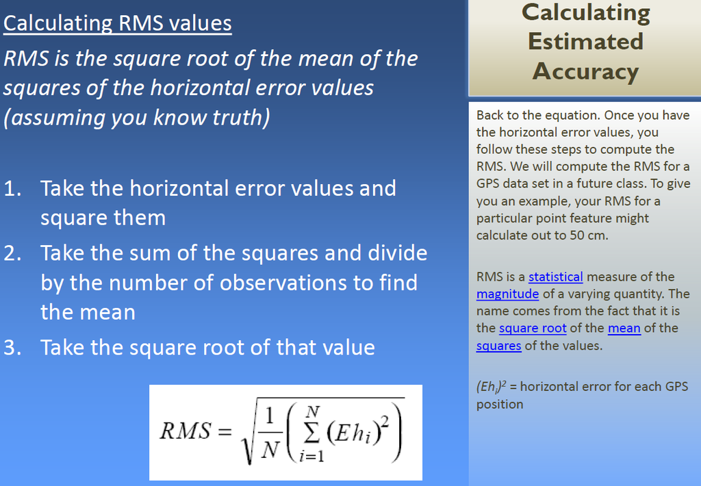

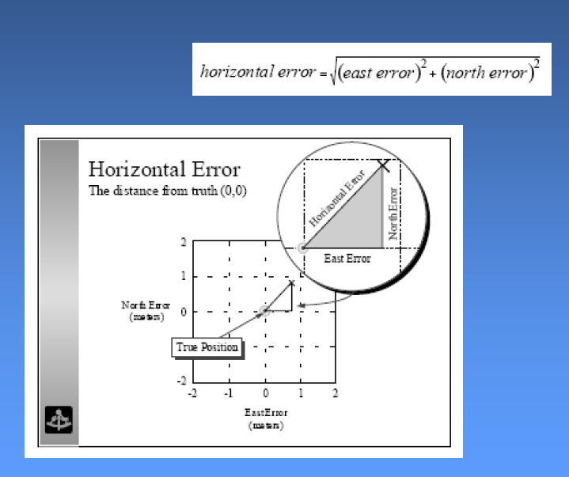

Lasketaan sisäisiä tarkkuuksia: vaaka-RMSE ja -2dRMSE. / Let's calculate inner accuracies (precision): Horizontal RMSE and 2dRMSE:

```python
def RMSE_horizontal_inner(coordinates1, mean1, coordinates2, mean2):
    horizontalerror_square = 0
    i = 0
    while i < len(coordinates1):
        horizontalerror_square += (np.sqrt((coordinates1[i] - mean1)**2 + (coordinates2[i] - mean2)**2))**2
        i += 1
    RMSE = np.sqrt(horizontalerror_square/len(coordinates1))
    return RMSE

RMSE_horizontal_inner = RMSE_horizontal_inner(northcoordinates, mean_n, eastcoordinates, mean_e)
# print(mean_n)
TWOdRMSE_horizontal_inner = RMSE_horizontal_inner * 2

print('The precision of the point (inner accuracy) Horizontal RMSE is {}m (63-68% of the measurements, depends on the shape of the distribution) and Horizontal 2dRMSE {}m (95-98% of the measurements, depends on the shape of the distribution).'.format(round(RMSE_horizontal_inner, 3), round(TWOdRMSE_horizontal_inner, 3)))
```

```
The precision of the point (inner accuracy) Horizontal RMSE is 0.02m (63-68% of the measurements, depends on the shape of the distribution) and Horizontal 2dRMSE 0.04m (95-98% of the measurements, depends on the shape of the distribution).
```

Lasketaan sisäisiä tarkkuuksia: korkeus-RMSE ja -2dRMSE. / Let's calculate inner accuracies (precision): Vertical RMSE and 2dRMSE:

```python
def RMSE_vertical_inner(coordinates, mean):
    verticalerror_square = 0
    i = 0
    while i < len(coordinates):
        verticalerror_square += (np.sqrt((coordinates[i] - mean)**2))**2
        i += 1
    RMSE = np.sqrt(verticalerror_square/len(coordinates))
    return RMSE

RMSE_vertical_inner = RMSE_vertical_inner(heights, mean_h)
TWOdRMSE_vertical_inner = RMSE_vertical_inner * 2

print('The precision of the point (inner accuracy) Vertical RMSE is {}m (63-68% of the measurements, depends on the shape of the distribution) and Vertical 2dRMSE {}m (95-98% of the measurements, depends on the shape of the distribution).'.format(round(RMSE_vertical_inner, 3), round(TWOdRMSE_vertical_inner, 3)))
```

```
The precision of the point (inner accuracy) Vertical RMSE is 0.025m (63-68% of the measurements, depends on the shape of the distribution) and Vertical 2dRMSE 0.05m (95-98% of the measurements, depends on the shape of the distribution).
```

Piirretään kuvaajat sisäisille tarkkuuksille: vaakatarkkuudet. / Let's draw the figures for inner accuracies (precisions): horizontal precisions:

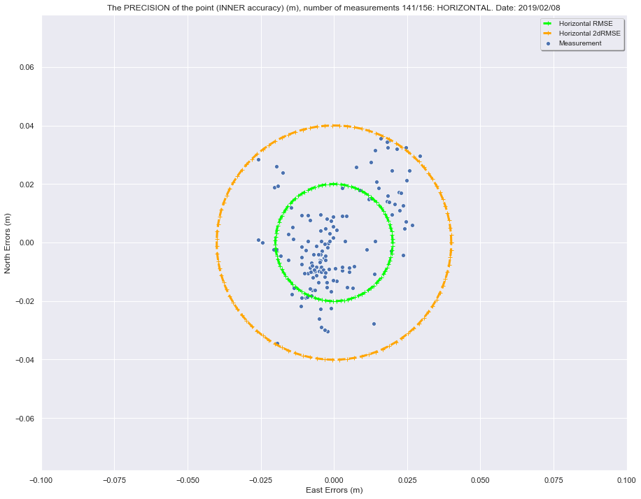

```python
def horizontal_errors_inner(coordinates1, mean1, coordinates2, mean2):
    horizontal_errors = np.zeros(shape=(len(coordinates1), 2))
    i = 0
    while i < len(coordinates1):
        horizontal_errors[i, 0] = coordinates1[i] - mean1
        horizontal_errors[i, 1] = coordinates2[i] - mean2
        i += 1
    return horizontal_errors

horizontal_errors_inner = horizontal_errors_inner(northcoordinates, mean_n, eastcoordinates, mean_e)
horizontal_errors_inner_df = pd.DataFrame({'North Errors (m)':horizontal_errors_inner[:,0],'East Errors (m)':horizontal_errors_inner[:,1]})
# print(horizontal_errors_inner_df)

fig = plt.figure(figsize=(15, 12))
sns.scatterplot(x = 'East Errors (m)', y = 'North Errors (m)', data = horizontal_errors_inner_df)
plt.title('The PRECISION of the point (INNER accuracy) (m), number of measurements {}/{}: HORIZONTAL. Date: {}'.format(len(northcoordinates), len(northcoordinates) + len(abovetolerances), date[1]))

an = np.linspace(0, 2 * np.pi, 100)
plt.plot(RMSE_horizontal_inner * np.cos(an), RMSE_horizontal_inner * np.sin(an), color = 'lime', marker = '+', linestyle = '--', linewidth = 3)
plt.plot(TWOdRMSE_horizontal_inner * np.cos(an), TWOdRMSE_horizontal_inner * np.sin(an), color = 'orange', marker = '+', linestyle = '--', linewidth = 3)
plt.axis('equal')
plt.axis([-0.1, 0.1, -0.1, 0.1])
plt.legend(('Horizontal RMSE', 'Horizontal 2dRMSE', 'Measurement'), loc = 1, shadow=True, handlelength=1.5, fontsize=10)
fig.savefig('{}\\figures\\G_The PRECISION of the point (INNER accuracy) (m) HORIZONTAL.png'.format(str(pathlib.Path.cwd())))
plt.show()

figures_df.loc[6, 'The Figure File Name'] = 'G_The PRECISION of the point (INNER accuracy) (m) HORIZONTAL.png'
```

Piirretään kuvaajat sisäisille tarkkuuksille: pohjoistarkkuudet. / Let's draw the figures for inner accuracies (precisions): North precisions:

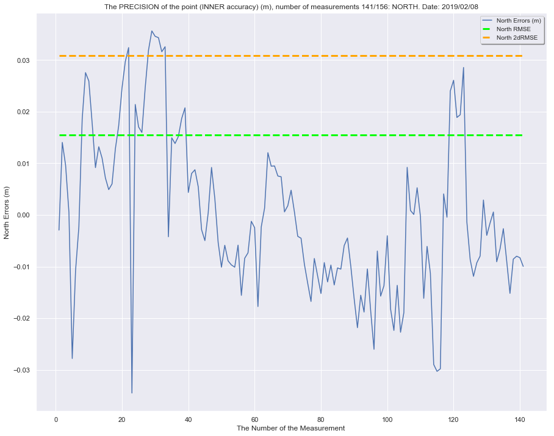

```python
def RMSE_north_inner(coordinates, mean):
    northerror_square = 0
    i = 0
    while i < len(coordinates):
        northerror_square += (np.sqrt((coordinates[i] - mean)**2))**2
        i += 1
    RMSE = np.sqrt(northerror_square/len(coordinates))
    return RMSE

RMSE_north_inner = RMSE_north_inner(northcoordinates, mean_n)
TWOdRMSE_north_inner = RMSE_north_inner * 2

def north_errors_inner(coordinates, mean):
    north_errors = np.zeros(shape=(len(coordinates), 2))
    i = 0
    while i < len(coordinates):
        north_errors[i, 0] = coordinates[i] - mean
        north_errors[i, 1] = i + 1
        i += 1
    return north_errors

north_errors_inner = north_errors_inner(northcoordinates, mean_n)
north_errors_inner_df = pd.DataFrame({'North Errors (m)':north_errors_inner[:,0], 'The Number of the Measurement':north_errors_inner[:,1]})

fig = plt.figure(figsize=(15, 12))
sns.lineplot(x = 'The Number of the Measurement', y = 'North Errors (m)', data = north_errors_inner_df)
plt.title('The PRECISION of the point (INNER accuracy) (m), number of measurements {}/{}: NORTH. Date: {}'.format(len(northcoordinates), len(northcoordinates) + len(abovetolerances), date[1]))
plt.plot([north_errors_inner_df.loc[0, 'The Number of the Measurement'], len(north_errors_inner_df)], [RMSE_north_inner, RMSE_north_inner], color = 'lime', linestyle = '--', linewidth = 3)
plt.plot([north_errors_inner_df.loc[0, 'The Number of the Measurement'], len(north_errors_inner_df)], [TWOdRMSE_north_inner, TWOdRMSE_north_inner], color = 'orange', linestyle = '--', linewidth = 3)
plt.legend(('North Errors (m)', 'North RMSE', 'North 2dRMSE'), loc = 1, shadow=True, handlelength=1.5, fontsize=10)
fig.savefig('{}\\figures\\H_The PRECISION of the point (INNER accuracy) (m) NORTH.png'.format(str(pathlib.Path.cwd())))
plt.show()

figures_df.loc[7, 'The Figure File Name'] = 'H_The PRECISION of the point (INNER accuracy) (m) NORTH.png'
```

Piirretään kuvaajat sisäisille tarkkuuksille: itätarkkuudet. / Let's draw the figures for inner accuracies (precisions): East precisions:

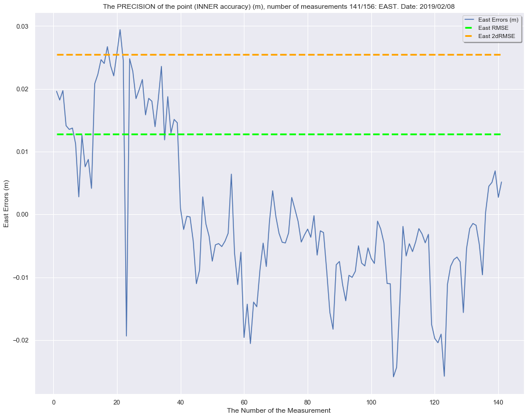

```python
def RMSE_east_inner(coordinates, mean):
    easterror_square = 0
    i = 0
    while i < len(coordinates):
        easterror_square += (np.sqrt((coordinates[i] - mean)**2))**2
        i += 1
    RMSE = np.sqrt(easterror_square/len(coordinates))
    return RMSE

RMSE_east_inner = RMSE_east_inner(eastcoordinates, mean_e)
TWOdRMSE_east_inner = RMSE_east_inner * 2

def east_errors_inner(coordinates, mean):
    east_errors = np.zeros(shape=(len(coordinates), 2))
    i = 0
    while i < len(coordinates):
        east_errors[i, 0] = coordinates[i] - mean
        east_errors[i, 1] = i + 1
        i += 1
    return east_errors

east_errors_inner = east_errors_inner(eastcoordinates, mean_e)
east_errors_inner_df = pd.DataFrame({'East Errors (m)':east_errors_inner[:,0], 'The Number of the Measurement':east_errors_inner[:,1]})

fig = plt.figure(figsize=(15, 12))
sns.lineplot(x = 'The Number of the Measurement', y = 'East Errors (m)', data = east_errors_inner_df)
plt.title('The PRECISION of the point (INNER accuracy) (m), number of measurements {}/{}: EAST. Date: {}'.format(len(eastcoordinates), len(eastcoordinates) + len(abovetolerances), date[1]))
plt.plot([east_errors_inner_df.loc[0, 'The Number of the Measurement'], len(east_errors_inner_df)], [RMSE_east_inner, RMSE_east_inner], color = 'lime', linestyle = '--', linewidth = 3)
plt.plot([east_errors_inner_df.loc[0, 'The Number of the Measurement'], len(east_errors_inner_df)], [TWOdRMSE_east_inner, TWOdRMSE_east_inner], color = 'orange', linestyle = '--', linewidth = 3)
plt.legend(('East Errors (m)', 'East RMSE', 'East 2dRMSE'), loc = 1, shadow=True, handlelength=1.5, fontsize=10)
fig.savefig('{}\\figures\\I_The PRECISION of the point (INNER accuracy) (m) EAST.png'.format(str(pathlib.Path.cwd())))
plt.show()

figures_df.loc[8, 'The Figure File Name'] = 'I_The PRECISION of the point (INNER accuracy) (m) EAST.png'
```

Piirretään kuvaajat sisäisille tarkkuuksille: vertikaalitarkkuudet. / Let's draw the figures for inner accuracies (precisions): Vertical precisions:

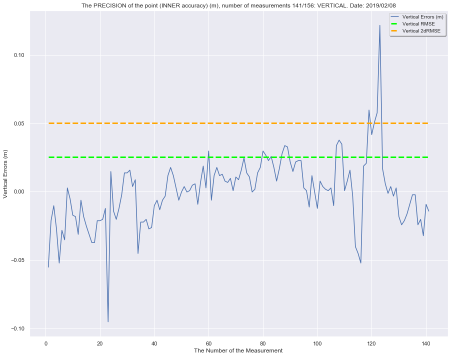

```python
def vertical_errors_inner(coordinates, mean):
    vertical_errors = np.zeros(shape=(len(coordinates), 2))
    i = 0
    while i < len(coordinates):
        vertical_errors[i, 0] = coordinates[i] - mean
        vertical_errors[i, 1] = i + 1
        i += 1
    return vertical_errors

vertical_errors_inner = vertical_errors_inner(heights, mean_h)
vertical_errors_inner_df = pd.DataFrame({'Vertical Errors (m)':vertical_errors_inner[:,0], 'The Number of the Measurement':vertical_errors_inner[:,1]})

fig = plt.figure(figsize=(15, 12))
sns.lineplot(x = 'The Number of the Measurement', y = 'Vertical Errors (m)', data = vertical_errors_inner_df)
plt.title('The PRECISION of the point (INNER accuracy) (m), number of measurements {}/{}: VERTICAL. Date: {}'.format(len(northcoordinates), len(northcoordinates) + len(abovetolerances), date[1]))
plt.plot([vertical_errors_inner_df.loc[0, 'The Number of the Measurement'], len(vertical_errors_inner_df)], [RMSE_vertical_inner, RMSE_vertical_inner], color = 'lime', linestyle = '--', linewidth = 3)
plt.plot([vertical_errors_inner_df.loc[0, 'The Number of the Measurement'], len(vertical_errors_inner_df)], [TWOdRMSE_vertical_inner, TWOdRMSE_vertical_inner], color = 'orange', linestyle = '--', linewidth = 3)
plt.legend(('Vertical Errors (m)', 'Vertical RMSE', 'Vertical 2dRMSE'), loc = 1, shadow=True, handlelength=1.5, fontsize=10)
fig.savefig('{}\\figures\\J_The PRECISION of the point (INNER accuracy) (m) VERTICAL.png'.format(str(pathlib.Path.cwd())))
plt.show()

figures_df.loc[9, 'The Figure File Name'] = 'J_The PRECISION of the point (INNER accuracy) (m) VERTICAL.png'
```

Lasketaan ulkoisia tarkkuuksia: vaaka-RMSE ja -2dRMSE. / Let's draw the figures for outer accuracies (accuracies): Horizontal RMSE and 2dRMSE.

```python
def RMSE_horizontal_outer(coordinates1, referencecoordinate1, coordinates2, referencecoordinate2):
    horizontalerror_square = 0
    i = 0
    while i < len(coordinates1):
        horizontalerror_square += (np.sqrt((coordinates1[i] - referencecoordinate1)**2 + (coordinates2[i] - referencecoordinate2)**2))**2
        i += 1
    RMSE = np.sqrt(horizontalerror_square/len(coordinates1))
    return RMSE

RMSE_horizontal_outer = RMSE_horizontal_outer(northcoordinates, referencecoordinate_n, eastcoordinates, referencecoordinate_e)
TWOdRMSE_horizontal_outer = RMSE_horizontal_outer * 2

print('The accuracy of the point (outer accuracy) Horizontal RMSE is {}m (63-68% of the measurements, depends on the shape of the distribution) and Horizontal 2dRMSE {}m (95-98% of the measurements, depends on the shape of the distribution).'.format(round(RMSE_horizontal_outer, 3), round(TWOdRMSE_horizontal_outer, 3)))
```

```
The accuracy of the point (outer accuracy) Horizontal RMSE is 0.031m (63-68% of the measurements, depends on the shape of the distribution) and Horizontal 2dRMSE 0.063m (95-98% of the measurements, depends on the shape of the distribution).
```

Lasketaan ulkoisia tarkkuuksia: korkeus-RMSE ja -2dRMSE. / Let's draw the figures for outer accuracies (accuracies): Vertical RMSE and 2dRMSE.

```python
def RMSE_vertical_outer(coordinates, referencecoordinate):
    verticalerror_square = 0
    i = 0
    while i < len(coordinates):
        verticalerror_square += (np.sqrt((coordinates[i] - referencecoordinate)**2))**2
        i += 1
    RMSE = np.sqrt(verticalerror_square/len(coordinates))
    return RMSE

RMSE_vertical_outer = RMSE_vertical_outer(heights, referencecoordinate_h)
TWOdRMSE_vertical_outer = RMSE_vertical_outer * 2

print('The accuracy of the point (outer accuracy) Vertical RMSE is {}m (63-68% of the measurements, depends on the shape of the distribution) and Vertical 2dRMSE {}m (95-98% of the measurements, depends on the shape of the distribution).'.format(round(RMSE_vertical_outer, 3), round(TWOdRMSE_vertical_outer, 3)))
```

```
The accuracy of the point (outer accuracy) Vertical RMSE is 0.033m (63-68% of the measurements, depends on the shape of the distribution) and Vertical 2dRMSE 0.066m (95-98% of the measurements, depends on the shape of the distribution).
```

Piirretään kuvaajat ulkoisille tarkkuuksille: vaakatarkkuudet. / Let's draw the figures for outer accuracies (accuracies): Horizontal accuracies:

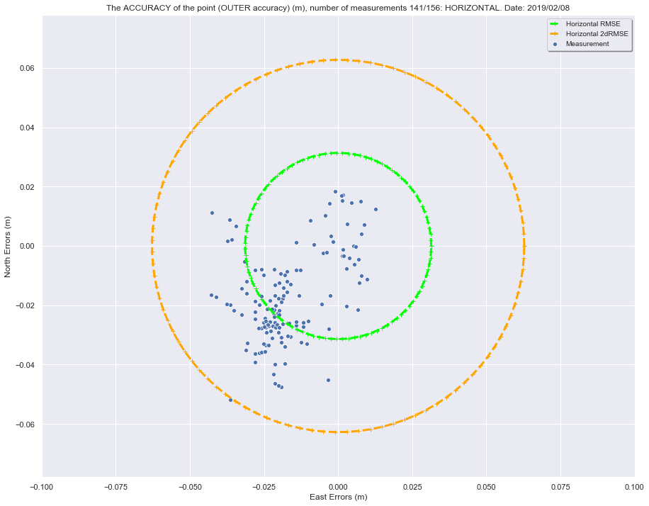

```python
def horizontal_errors_outer(coordinates1, referencecoordinate1, coordinates2, referencecoordinate2):
    horizontal_errors = np.zeros(shape=(len(coordinates1), 2))
    i = 0
    while i < len(coordinates1):
        horizontal_errors[i, 0] = coordinates1[i] - referencecoordinate1
        horizontal_errors[i, 1] = coordinates2[i] - referencecoordinate2
        i += 1
    return horizontal_errors

horizontal_errors_outer = horizontal_errors_outer(northcoordinates, referencecoordinate_n, eastcoordinates, referencecoordinate_e)
horizontal_errors_outer_df = pd.DataFrame({'North Errors (m)':horizontal_errors_outer[:,0],'East Errors (m)':horizontal_errors_outer[:,1]})

fig = plt.figure(figsize=(15, 12))
sns.scatterplot(x = 'East Errors (m)', y = 'North Errors (m)', data = horizontal_errors_outer_df)
plt.title('The ACCURACY of the point (OUTER accuracy) (m), number of measurements {}/{}: HORIZONTAL. Date: {}'.format(len(northcoordinates), len(northcoordinates) + len(abovetolerances), date[1]))

an = np.linspace(0, 2 * np.pi, 100)
plt.plot(RMSE_horizontal_outer * np.cos(an), RMSE_horizontal_outer * np.sin(an), color = 'lime', marker = '+', linestyle = '--', linewidth = 3)
plt.plot(TWOdRMSE_horizontal_outer * np.cos(an), TWOdRMSE_horizontal_outer * np.sin(an), color = 'orange', marker = '+', linestyle = '--', linewidth = 3)
plt.axis('equal')
plt.axis([-0.1, 0.1, -0.1, 0.1])
plt.legend(('Horizontal RMSE', 'Horizontal 2dRMSE', 'Measurement'), loc = 1, shadow=True, handlelength=1.5, fontsize=10)
fig.savefig('{}\\figures\\K_The ACCURACY of the point (OUTER accuracy) (m) HORIZONTAL.png'.format(str(pathlib.Path.cwd())))
plt.show()

figures_df.loc[10, 'The Figure File Name'] = 'K_The ACCURACY of the point (OUTER accuracy) (m) HORIZONTAL.png'
```

Piirretään kuvaajat ulkoisille tarkkuuksille. pohjoistarkkuudet. / Let's draw the figures for outer accuracies (accuracies): North accuracies:

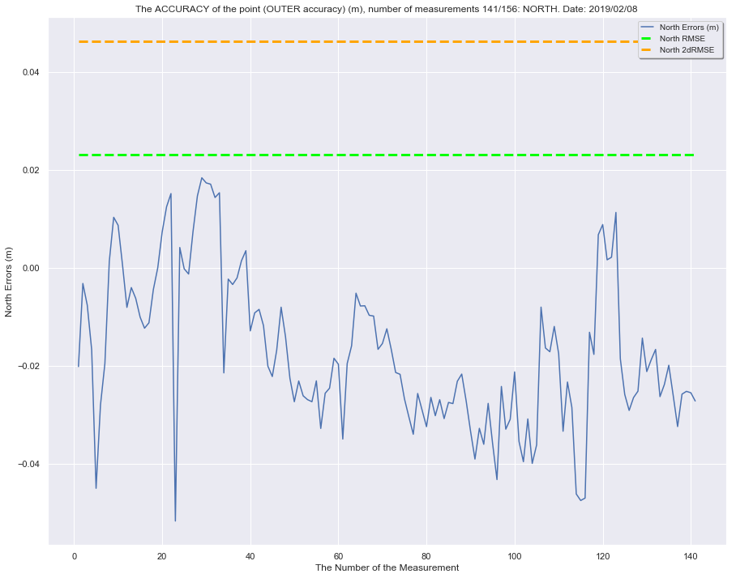

```python
def RMSE_north_outer(coordinates, referencecoordinate):
    northerror_square = 0
    i = 0
    while i < len(coordinates):
        northerror_square += (np.sqrt((coordinates[i] - referencecoordinate)**2))**2
        i += 1
    RMSE = np.sqrt(northerror_square/len(coordinates))
    return RMSE

RMSE_north_outer = RMSE_north_outer(northcoordinates, referencecoordinate_n)
TWOdRMSE_north_outer = RMSE_north_outer * 2

def north_errors_outer(coordinates, referencecoordinate):
    north_errors = np.zeros(shape=(len(coordinates), 2))
    i = 0
    while i < len(coordinates):
        north_errors[i, 0] = coordinates[i] - referencecoordinate
        north_errors[i, 1] = i + 1
        i += 1
    return north_errors

north_errors_outer = north_errors_outer(northcoordinates, referencecoordinate_n)
north_errors_outer_df = pd.DataFrame({'North Errors (m)':north_errors_outer[:,0], 'The Number of the Measurement':north_errors_outer[:,1]})

fig = plt.figure(figsize=(15, 12))
sns.lineplot(x = 'The Number of the Measurement', y = 'North Errors (m)', data = north_errors_outer_df)
plt.title('The ACCURACY of the point (OUTER accuracy) (m), number of measurements {}/{}: NORTH. Date: {}'.format(len(northcoordinates), len(northcoordinates) + len(abovetolerances), date[1]))
plt.plot([north_errors_outer_df.loc[0, 'The Number of the Measurement'], len(north_errors_outer_df)], [RMSE_north_outer, RMSE_north_outer], color = 'lime', linestyle = '--', linewidth = 3)
plt.plot([north_errors_outer_df.loc[0, 'The Number of the Measurement'], len(north_errors_outer_df)], [TWOdRMSE_north_outer, TWOdRMSE_north_outer], color = 'orange', linestyle = '--', linewidth = 3)
plt.legend(('North Errors (m)', 'North RMSE', 'North 2dRMSE'), loc = 1, shadow=True, handlelength=1.5, fontsize=10)
fig.savefig('{}\\figures\\L_The ACCURACY of the point (OUTER accuracy) (m) NORTH.png'.format(str(pathlib.Path.cwd())))
plt.show()

figures_df.loc[11, 'The Figure File Name'] = 'L_The ACCURACY of the point (OUTER accuracy) (m) NORTH.png'
```

Piirretään kuvaajat ulkoisille tarkkuuksille: itätarkkuudet. / Let's draw the figures for outer accuracies (accuracies): East accuracies:

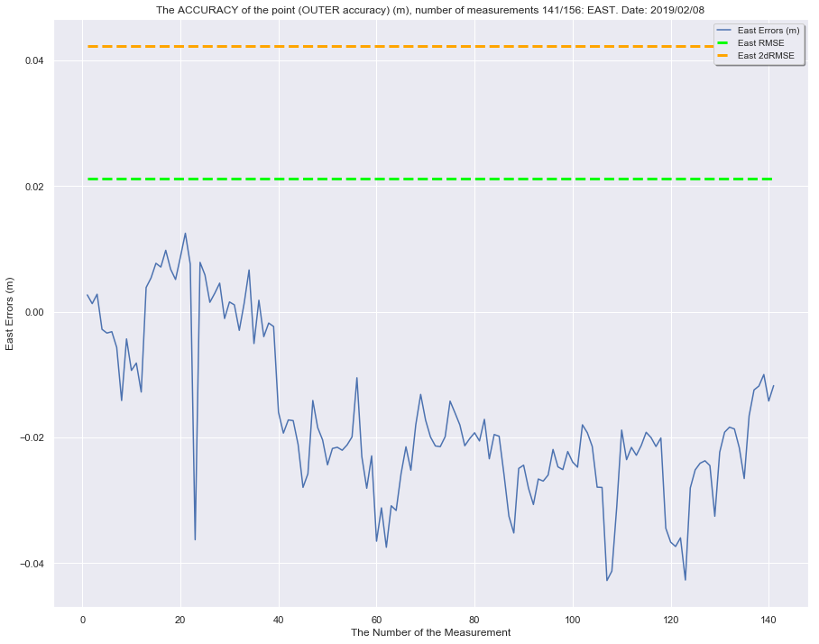

```python
def RMSE_east_outer(coordinates, referencecoordinate):
    easterror_square = 0
    i = 0
    while i < len(coordinates):
        easterror_square += (np.sqrt((coordinates[i] - referencecoordinate)**2))**2
        i += 1
    RMSE = np.sqrt(easterror_square/len(coordinates))
    return RMSE

RMSE_east_outer = RMSE_east_outer(eastcoordinates, referencecoordinate_e)
TWOdRMSE_east_outer = RMSE_east_outer * 2

def east_errors_outer(coordinates, referencecoordinate):
    east_errors = np.zeros(shape=(len(coordinates), 2))
    i = 0
    while i < len(coordinates):
        east_errors[i, 0] = coordinates[i] - referencecoordinate
        east_errors[i, 1] = i + 1
        i += 1
    return east_errors

east_errors_outer = east_errors_outer(eastcoordinates, referencecoordinate_e)
east_errors_outer_df = pd.DataFrame({'East Errors (m)':east_errors_outer[:,0], 'The Number of the Measurement':east_errors_outer[:,1]})

fig = plt.figure(figsize=(15, 12))
sns.lineplot(x = 'The Number of the Measurement', y = 'East Errors (m)', data = east_errors_outer_df)
plt.title('The ACCURACY of the point (OUTER accuracy) (m), number of measurements {}/{}: EAST. Date: {}'.format(len(eastcoordinates), len(eastcoordinates) + len(abovetolerances), date[1]))
plt.plot([east_errors_outer_df.loc[0, 'The Number of the Measurement'], len(east_errors_outer_df)], [RMSE_east_outer, RMSE_east_outer], color = 'lime', linestyle = '--', linewidth = 3)
plt.plot([east_errors_outer_df.loc[0, 'The Number of the Measurement'], len(east_errors_outer_df)], [TWOdRMSE_east_outer, TWOdRMSE_east_outer], color = 'orange', linestyle = '--', linewidth = 3)
plt.legend(('East Errors (m)', 'East RMSE', 'East 2dRMSE'), loc = 1, shadow=True, handlelength=1.5, fontsize=10)
fig.savefig('{}\\figures\\M_The ACCURACY of the point (OUTER accuracy) (m) EAST.png'.format(str(pathlib.Path.cwd())))
plt.show()

figures_df.loc[12, 'The Figure File Name'] = 'M_The ACCURACY of the point (OUTER accuracy) (m) EAST.png'
```

Piirretään kuvaajat ulkoisille tarkkuuksille: vertikaalitarkkuudet. / Let's draw the figures for outer accuracies (accuracies): Vertical accuracies:

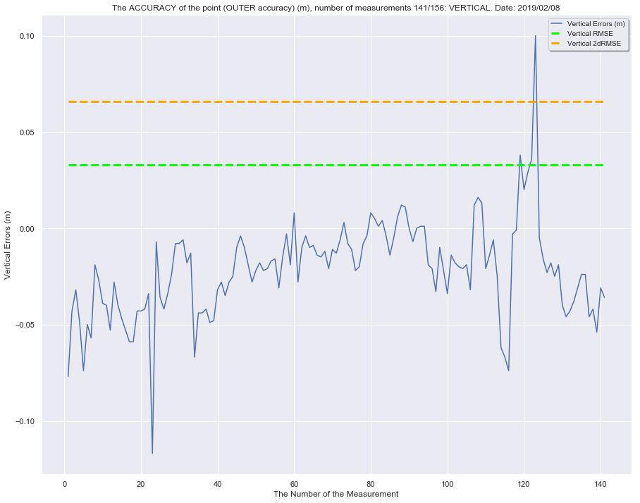

```python
def RMSE_vertical_outer(coordinates, referencecoordinate):
    verticalerror_square = 0
    i = 0
    while i < len(coordinates):
        verticalerror_square += (np.sqrt((coordinates[i] - referencecoordinate)**2))**2
        i += 1
    RMSE = np.sqrt(verticalerror_square/len(coordinates))
    return RMSE

RMSE_vertical_outer = RMSE_vertical_outer(heights, referencecoordinate_h)
TWOdRMSE_vertical_outer = RMSE_vertical_outer * 2

def vertical_errors_outer(coordinates, referencecoordinate):
    vertical_errors = np.zeros(shape=(len(coordinates), 2))
    i = 0
    while i < len(coordinates):
        vertical_errors[i, 0] = coordinates[i] - referencecoordinate
        vertical_errors[i, 1] = i + 1
        i += 1
    return vertical_errors

vertical_errors_outer = vertical_errors_outer(heights, referencecoordinate_h)
vertical_errors_outer_df = pd.DataFrame({'Vertical Errors (m)':vertical_errors_outer[:,0], 'The Number of the Measurement':vertical_errors_outer[:,1]})

fig = plt.figure(figsize=(15, 12))
sns.lineplot(x = 'The Number of the Measurement', y = 'Vertical Errors (m)', data = vertical_errors_outer_df)
plt.title('The ACCURACY of the point (OUTER accuracy) (m), number of measurements {}/{}: VERTICAL. Date: {}'.format(len(heights), len(heights) + len(abovetolerances), date[1]))
plt.plot([vertical_errors_outer_df.loc[0, 'The Number of the Measurement'], len(vertical_errors_outer_df)], [RMSE_vertical_outer, RMSE_vertical_outer], color = 'lime', linestyle = '--', linewidth = 3)
plt.plot([vertical_errors_outer_df.loc[0, 'The Number of the Measurement'], len(vertical_errors_outer_df)], [TWOdRMSE_vertical_outer, TWOdRMSE_vertical_outer], color = 'orange', linestyle = '--', linewidth = 3)
plt.legend(('Vertical Errors (m)', 'Vertical RMSE', 'Vertical 2dRMSE'), loc = 1, shadow=True, handlelength=1.5, fontsize=10)
fig.savefig('{}\\figures\\N_The ACCURACY of the point (OUTER accuracy) (m) VERTICAL.png'.format(str(pathlib.Path.cwd())))

plt.show()

figures_df.loc[13, 'The Figure File Name'] = 'N_The ACCURACY of the point (OUTER accuracy) (m) VERTICAL.png'
```

Piirretään kuvaajat sisäisille tarkkuuksille ja DOP-arvoille havaintojen funktiona: vaakatarkkuudet. / Let's draw the figures for inner accuracies (precisions) and DOP values as a function of the measurements: horizontal precisions:

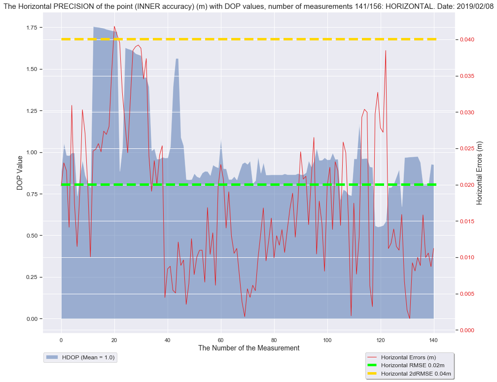

```python
horizontal_errors_inner_df['Horizontal Errors (m)'] = ((horizontal_errors_inner_df.loc[:, 'East Errors (m)'])**2 + (horizontal_errors_inner_df.loc[:, 'North Errors (m)'])**2).pow(1./2)
horizontal_errors_inner_df['The Number of the Measurement'] = range(0, len(horizontal_errors_inner_df))
x = range(len(testmeasurements_df_no_outliers.loc[:, 'HDOP']))
y = [testmeasurements_df_no_outliers.loc[:, 'HDOP']]
mean_HDOP = round(testmeasurements_df_no_outliers.loc[:, 'HDOP'].mean(), 1)

fig, ax1 = plt.subplots(figsize=(15, 12))
ax1.stackplot(x, y, labels=['HDOP (Mean = {})'.format(mean_HDOP)], alpha=0.5)
ax1.set_xlabel('The Number of the Measurement', fontsize=14)
ax1.set_ylabel('DOP Value', fontsize=14)
ax1.legend(bbox_to_anchor=(-0.005, -0.1), loc='lower left', fontsize=12)
ax1.tick_params(axis='y', labelsize = 12)

color = (0.8941176470588236, 0.10196078431372549, 0.10980392156862745)
ax2 = ax1.twinx()
ax2 = sns.lineplot(x = 'The Number of the Measurement', y = 'Horizontal Errors (m)', data = horizontal_errors_inner_df, color = color, linewidth = 1)
ax2.set_title('The Horizontal PRECISION of the point (INNER accuracy) (m) with DOP values, number of measurements {}/{}: HORIZONTAL. Date: {}'.format(len(horizontal_errors_inner_df), len(horizontal_errors_inner_df) + len(abovetolerances), date[1]), fontsize=15)
ax2.set_ylabel('Horizontal Errors (m)', fontsize = 14)
ax3 = plt.plot([horizontal_errors_inner_df.loc[0, 'The Number of the Measurement'], len(horizontal_errors_inner_df)], [RMSE_horizontal_inner, RMSE_horizontal_inner], color = 'lime', linestyle = '--', linewidth = 5)
ax4 = plt.plot([horizontal_errors_inner_df.loc[0, 'The Number of the Measurement'], len(horizontal_errors_inner_df)], [TWOdRMSE_horizontal_inner, TWOdRMSE_horizontal_inner], color = 'gold', linestyle = '--', linewidth = 5)
ax2.legend(('Horizontal Errors (m)', 'Horizontal RMSE {}m'.format(round(RMSE_horizontal_inner, 3)), 'Horizontal 2dRMSE {}m'.format(round(TWOdRMSE_horizontal_inner, 3))), shadow=True, handlelength=1.5, fontsize=12, bbox_to_anchor=(0.775, -0.15), loc = 'lower left')
ax2.tick_params(axis='y', labelcolor=color, labelsize = 12)
fig.savefig('{}\\figures\\O_The Horizontal PRECISION of the point (INNER accuracy) (m) with DOP values.png'.format(str(pathlib.Path.cwd())))

plt.show()

figures_df.loc[14, 'The Figure File Name'] = 'O_The Horizontal PRECISION of the point (INNER accuracy) (m) with DOP values.png'
```

Piirretään kuvaajat sisäisille tarkkuuksille ja DOP-arvoille havaintojen funktiona: 3D-tarkkuudet. / Let's draw the figures for inner accuracies (precisions) and DOP values as a function of the measurements: 3D precisions:

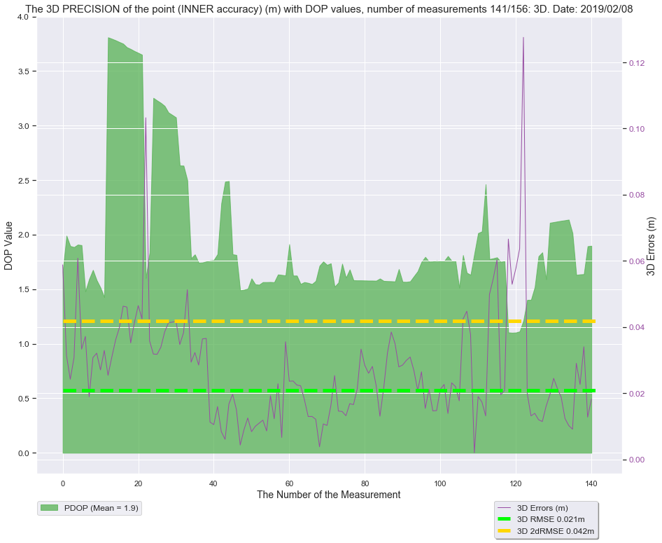

```python
def THREED_errors_inner(coordinates1, mean1, coordinates2, mean2, coordinates3, mean3):
    THREED_errors = np.zeros(shape=(len(coordinates1), 3))
    i = 0
    while i < len(coordinates1):
        THREED_errors[i, 0] = coordinates1[i] - mean1
        THREED_errors[i, 1] = coordinates2[i] - mean2
        THREED_errors[i, 2] = coordinates3[i] - mean3
        i += 1
    return THREED_errors

THREED_errors_inner = THREED_errors_inner(northcoordinates, mean_n, eastcoordinates, mean_e, heights, mean_h)
THREED_errors_inner_df = pd.DataFrame({'North Errors (m)':THREED_errors_inner[:,0], 'East Errors (m)':THREED_errors_inner[:,1], 'Height Errors (m)':THREED_errors_inner[:,2]})
# print(THREED_errors_inner_df)

# ----------------------------------------------------------------------------------
def RMSE_THREED_inner(coordinates1, mean1, coordinates2, mean2, coordinates3, mean3):
    THREEDerror_square = 0
    i = 0
    while i < len(coordinates1):
        THREEDerror_square += (np.sqrt((coordinates1[i] - mean1)**2 + (coordinates2[i] - mean2)**2) + (coordinates3[i] - mean3)**2)**2
        i += 1
    RMSE = np.sqrt(THREEDerror_square/len(coordinates1))
    return RMSE

RMSE_THREED_inner = RMSE_THREED_inner(northcoordinates, mean_n, eastcoordinates, mean_e, heights, mean_h)
TWOdRMSE_THREED_inner = RMSE_THREED_inner * 2

# ----------------------------------------------------------------------------------

THREED_errors_inner_df['3D Errors (m)'] = ((THREED_errors_inner_df.loc[:, 'East Errors (m)'])**2 + (THREED_errors_inner_df.loc[:, 'North Errors (m)'])**2 + (THREED_errors_inner_df.loc[:, 'Height Errors (m)'])**2).pow(1./2)
THREED_errors_inner_df['The Number of the Measurement'] = range(0, len(THREED_errors_inner_df))
x = range(len(testmeasurements_df_no_outliers.loc[:, 'HDOP']))
y = [testmeasurements_df_no_outliers.loc[:, 'PDOP']]
mean_PDOP = round(testmeasurements_df_no_outliers.loc[:, 'PDOP'].mean(), 1)

fig, ax1 = plt.subplots(figsize=(15, 12))
ax1.stackplot(x, y, labels=['PDOP (Mean = {})'.format(mean_PDOP)], color = (0.30196078431372547, 0.6862745098039216, 0.2901960784313726), alpha=0.7)
ax1.set_xlabel('The Number of the Measurement', fontsize=14)
ax1.set_ylabel('DOP Value', fontsize=14)
ax1.legend(bbox_to_anchor=(-0.005, -0.1), loc='lower left', fontsize=12)
ax1.tick_params(axis='y', labelsize = 12)

color = (0.596078431372549, 0.3058823529411765, 0.6392156862745098)
ax2 = ax1.twinx()
ax2 = sns.lineplot(x = 'The Number of the Measurement', y = '3D Errors (m)', data = THREED_errors_inner_df, color = color, linewidth = 1)
ax2.set_title('The 3D PRECISION of the point (INNER accuracy) (m) with DOP values, number of measurements {}/{}: 3D. Date: {}'.format(len(THREED_errors_inner_df), len(THREED_errors_inner_df) + len(abovetolerances), date[1]), fontsize=15)
ax2.set_ylabel('3D Errors (m)', fontsize = 14)
ax3 = plt.plot([THREED_errors_inner_df.loc[0, 'The Number of the Measurement'], len(THREED_errors_inner_df)], [RMSE_THREED_inner, RMSE_THREED_inner], color = 'lime', linestyle = '--', linewidth = 5)
ax4 = plt.plot([THREED_errors_inner_df.loc[0, 'The Number of the Measurement'], len(THREED_errors_inner_df)], [TWOdRMSE_THREED_inner, TWOdRMSE_THREED_inner], color = 'gold', linestyle = '--', linewidth = 5)
ax2.legend(('3D Errors (m)', '3D RMSE {}m'.format(round(RMSE_THREED_inner, 3)), '3D 2dRMSE {}m'.format(round(TWOdRMSE_THREED_inner, 3))), shadow=True, handlelength=1.5, fontsize=12, bbox_to_anchor=(0.775, -0.15), loc = 'lower left')
ax2.tick_params(axis='y', labelcolor=color, labelsize = 12)
fig.savefig('{}\\figures\\P_The 3D PRECISION of the point (INNER accuracy) (m) with DOP values.png'.format(str(pathlib.Path.cwd())))

plt.show()

figures_df.loc[15, 'The Figure File Name'] = 'P_The 3D PRECISION of the point (INNER accuracy) (m) with DOP values.png'
```

Piirretään kuvaajat sisäisille tarkkuuksille ja DOP-arvoille havaintojen funktiona: vertikaalitarkkuudet. / Let's draw the figures for inner accuracies (precisions) and DOP values as a function of the measurements: vertical precisions::

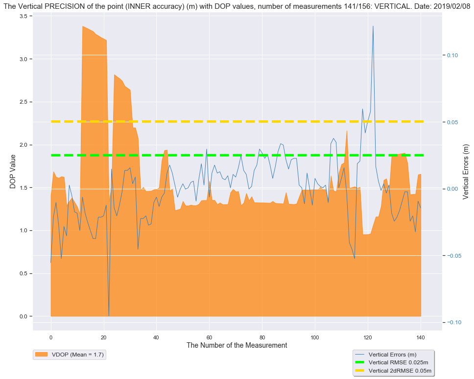

```python
vertical_errors_inner_df['The Number of the Measurement'] = range(0, len(vertical_errors_inner_df))
x = range(len(testmeasurements_df_no_outliers.loc[:, 'HDOP']))
y = [testmeasurements_df_no_outliers.loc[:, 'VDOP']]
mean_VDOP = round(testmeasurements_df_no_outliers.loc[:, 'VDOP'].mean(), 1)

fig, ax1 = plt.subplots(figsize=(15, 12))
ax1.stackplot(x, y, labels=['VDOP (Mean = {})'.format(mean_VDOP)], alpha=0.7, color = (1.0, 0.4980392156862745, 0.0))
ax1.set_xlabel('The Number of the Measurement', fontsize=14)
ax1.set_ylabel('DOP Value', fontsize=14)
ax1.legend(bbox_to_anchor=(-0.005, -0.1), loc='lower left', fontsize=12)
ax1.tick_params(axis='y', labelsize = 12)

color = (0.21568627450980393, 0.49411764705882355, 0.7215686274509804)
ax2 = ax1.twinx()
ax2 = sns.lineplot(x = 'The Number of the Measurement', y = 'Vertical Errors (m)', data = vertical_errors_inner_df, color = color, linewidth = 1)
ax2.set_title('The Vertical PRECISION of the point (INNER accuracy) (m) with DOP values, number of measurements {}/{}: VERTICAL. Date: {}'.format(len(vertical_errors_inner_df), len(vertical_errors_inner_df) + len(abovetolerances), date[1]), fontsize=15)
ax2.set_ylabel('Vertical Errors (m)', fontsize = 14)
ax3 = plt.plot([vertical_errors_inner_df.loc[0, 'The Number of the Measurement'], len(vertical_errors_inner_df)], [RMSE_vertical_inner, RMSE_vertical_inner], color = 'lime', linestyle = '--', linewidth = 5)
ax4 = plt.plot([vertical_errors_inner_df.loc[0, 'The Number of the Measurement'], len(vertical_errors_inner_df)], [TWOdRMSE_vertical_inner, TWOdRMSE_vertical_inner], color = 'gold', linestyle = '--', linewidth = 5)
ax2.legend(('Vertical Errors (m)', 'Vertical RMSE {}m'.format(round(RMSE_vertical_inner, 3)), 'Vertical 2dRMSE {}m'.format(round(TWOdRMSE_vertical_inner, 3))), shadow=True, handlelength=1.5, fontsize=12, bbox_to_anchor=(0.775, -0.15), loc = 'lower left')
ax2.tick_params(axis='y', labelcolor=color, labelsize = 12)
fig.savefig('{}\\figures\\Q_The Vertical PRECISION of the point (INNER accuracy) (m) with DOP values.png'.format(str(pathlib.Path.cwd())))

plt.show()

figures_df.loc[16, 'The Figure File Name'] = 'Q_The Vertical PRECISION of the point (INNER accuracy) (m) with DOP values.png'
```

Tehdään .pdf-tiedosto. (KESKEN) / Let's produce a .pdf-file (IN PROGRESS):

```python
# https://www.reportlab.com/docs/reportlab-userguide.pdf
# https://leanpub.com/reportlab
# https://www.blog.pythonlibrary.org/2010/03/08/a-simple-step-by-step-reportlab-tutorial/

import glob
import re

from reportlab.lib.styles import ParagraphStyle as PS
from reportlab.platypus import SimpleDocTemplate, Paragraph, Image, PageBreak
from reportlab.platypus.doctemplate import PageTemplate, BaseDocTemplate
from reportlab.platypus.doctemplate import Frame
from reportlab.platypus.tableofcontents import TableOfContents
from reportlab.lib.pagesizes import A1, A2, A3, A4
from reportlab.lib.units import cm
import string
import datetime

# ------------------------------------------------------------------------------------------
class MyDocTemplate(BaseDocTemplate):

    def __init__(self, filename, **kw):
        self.allowSplitting = 0
        BaseDocTemplate.__init__(self, filename, **kw)
        template = PageTemplate('normal', [Frame(2.5*cm, 2.5*cm, 15*cm, 25*cm, id='F1')])
        self.addPageTemplates(template)

    def afterFlowable(self, flowable):
        "Registers TOC entries."
        if flowable.__class__.__name__ == 'Paragraph':
            text = flowable.getPlainText()
            style = flowable.style.name
            if style == 'Heading1':
                self.notify('TOCEntry', (0, text, self.page))
            if style == 'Heading2':
                self.notify('TOCEntry', (1, text, self.page))

h1 = PS(name = 'Heading1', fontSize = 14, leading = 16)
h2 = PS(name = 'Heading2', fontSize = 12, leading = 14, leftIndent = 1*cm)
# ------------------------------------------------------------------------------------------
def create_pdf(fname, front_cover, back_cover, path):
    filename = os.path.join(path, fname + ".pdf")
    doc = SimpleDocTemplate(filename, pagesize = A4, rightMargin = 0, leftMargin= 0, topMargin = 0, bottomMargin= 0)
    Story=[]
    toc = TableOfContents()
    width = 12.5*cm
    height = 6*cm
    figs = []
    toc.levelStyles = [h1, h2]
    Story.append(Paragraph('This PDF document was produced:', PS('body')))
    now1 = str(datetime.datetime.now())
    Story.append(Paragraph(now1, PS('body')))
    Story.append(Image(front_cover, width, height))
    credits = ('\n\n\nAuthor: Tuukka Mattila.\nDo not hesitate to contact via LinkedIn: https://www.linkedin.com/in/tuukkamattila/.\n\nThank you for the help: Topi Rikkinen, Marko Ollikainen, Antti Laaksonen, Hannu Koivula, and Ari Huvinen').replace('\n','<br />\n')
    Story.append(Paragraph(credits, PS('body')))
    Story.append(PageBreak())
    Story.append(toc)
    Story.append(PageBreak())
    Story.append(Paragraph('The Figures', h1))
    Story.append(Paragraph('These are the figures, which NLS GNSS SOFAMESA produces.', PS('body')))
    Story.append(PageBreak())
    for index, row in figures_df.itertuples():
        Story.append(Paragraph(row, h2))
        width1 = 20*cm
        height1 = 15*cm
        im = Image(pathlib.Path(path).joinpath(row), width1, height1)
        im.hAlign = 'CENTER'
        Story.append(im)
        Story.append(PageBreak())
    Story.append(PageBreak())
    Story.append(Paragraph('Conclusions', h1))
    Story.append(PageBreak())
    Story.append(Paragraph('This PDF document was produced:', PS('body')))
    now1 = str(datetime.datetime.now())
    Story.append(Paragraph(now1, PS('body')))
    Story.append(Image(back_cover, width, height))
    Story.append(Paragraph(credits, PS('body')))

    doc = MyDocTemplate('Measurement_Report.pdf')
    doc.multiBuild(Story)

    # print("{} created".format(filename))

#----------------------------------------------------------------------
if __name__ == "__main__":
    path_figures = pathlib.Path(pathlib.Path(pathlib.Path.cwd()).joinpath("figures"))
    path_pdf_accessories = pathlib.Path(pathlib.Path(pathlib.Path.cwd()).joinpath("for_the_pdf_report"))
    front_cover = os.path.join(path_pdf_accessories, "NLS_logo1.jpg")
    back_cover = os.path.join(path_pdf_accessories, "NLS_logo2.jpg")
    filename = "Measurement_Report"
    create_pdf(filename, front_cover, back_cover, path_figures)
```

```python
time_ending = time.time()
display(Markdown('**This program took {}s to finish!**'.format(round(time_ending-time_beginning, 2))))
```

**This program took 29.9s to finish!**

[figure not shown]

```
                Author: Tuukka Mattila
                Do not hesitate to contact via LinkedIn:
                https://www.linkedin.com/in/tuukkamattila/

                Thank you for the help: Topi Rikkinen, Marko Ollikainen, Antti Laaksonen, Hannu Koivula, and Ari Huvinen
```